# `nano-lazar`: A framework for nanoparticle read across risk assessment

Christoph Helma, Micha Rautenberg, Denis Gebele

in silico toxicology gmbh, Basel, Switzerland

[figure not shown]

# `nano-lazar` framework

Framework for reproducible read-across (k-nearest-neighbor) predictions

For a given query substance (nanoparticle)

- Find similar substances (neighbors)
- Create local model with neighbor activities
- Apply local model to predict the query substance

# `nano-lazar` algorithms

Free choice of algorithms and parameters for

- Descriptors (measured, calculated)
- Feature selection
- Similarity calculation
- Local QSAR models

Reasonable default algorithms and parameters

# `nano-lazar` experiments

**Endpoint:**

Net cell association (121 Gold and Silver particles)

**Descriptors:**

Calculated fingerprints (new development), measured physchem properties, protein interactions

**Feature selection:**

Correlation filter (measured properties)

**Similarity:**

Weighted cosine (measured properties), Tanimoto/Jaccard (fingerprints)

**Local regression:**

Weighted average, partial least squares (PLS), random forests (RF)

- Five independent 10-fold crossvalidations
- *No* fixed random seed for training/test set splits, to avoid overfitting and to demonstrate the variability of validation results due to random training/test splits.
- Separate feature selection for each training dataset to avoid overfitting

# `nano-lazar` validation results

| Descriptors | Algorithm | RMSE | *r*<sup>2</sup> | % measurements within prediction interval |
| --- | --- | --- | --- | --- |
| MP2D | WA | *2.04 2.0 2.02 2.07 2.07* | *0.24 0.27 0.25 0.22 0.22* | NA |
| MP2D | PLS | *2.14 2.11 2.21 1.99 1.9* | *0.27 0.26 0.26 0.32 0.36* | 94 97 91 91 97 |
| MP2D | RF | 1.84 1.67 1.68 1.69 1.71 | *0.4 0.5 0.49 0.48 0.47* | 94 96 96 94 94 |
| P-CHEM | WA | *1.91 1.93 1.91 2.03 2.02* | *0.48 0.47 0.49 0.41 0.42* | NA |
| P-CHEM | PLS | *2.2 2.33 2.11 2.27 2.21* | *0.34 0.28 0.38 0.31 0.33* | 97 92 96 93 91 |
| P-CHEM | RF | 1.8 1.82 1.77 1.68 1.86 | 0.54 0.53 0.56 0.6 0.51 | **94 96 97 97 93** |
| Proteomics | WA | 1.94 1.63 1.7 1.61 1.76 | 0.49 0.64 0.6 0.64 0.57 | NA |
| Proteomics | PLS | 1.67 1.63 1.86 1.74 1.8 | 0.62 0.64 0.53 0.59 0.56 | *90 88 84 89 88* |
| Proteomics | RF | **1.66 1.69 1.81 1.68 1.6** | **0.62 0.61 0.57 0.6 0.65** | *89 89 89 87 89* |
| P-CHEM Proteomics | WA | 1.61 1.56 1.71 1.66 2.41 | 0.64 0.66 0.6 0.62 0.33 | NA |
| P-CHEM Proteomics | PLS | 1.74 1.67 1.78 1.71 2.18 | 0.6 0.62 0.59 0.61 0.43 | *91 90 86 85 86* |
| P-CHEM Proteomics | RF | *1.78 1.62 1.56 1.82 1.77* | *0.57 0.64 0.66 0.55 0.61* | *88 87 87 89 90* |

Gold *and* silver particles included!

# `nano-lazar` prediction/measurement correlation

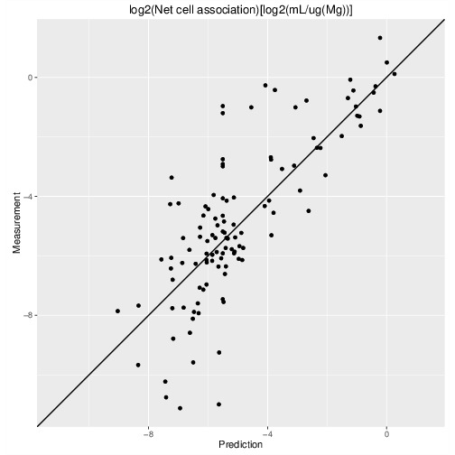

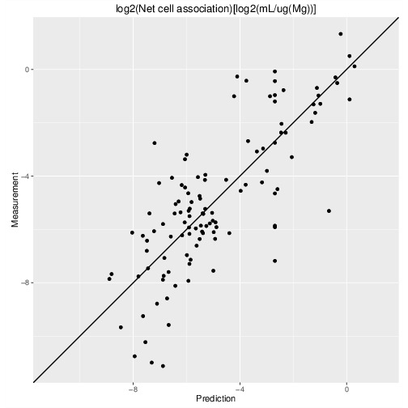

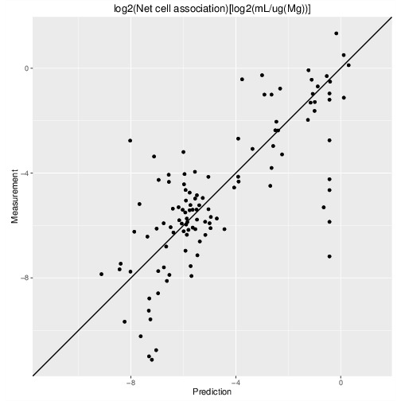

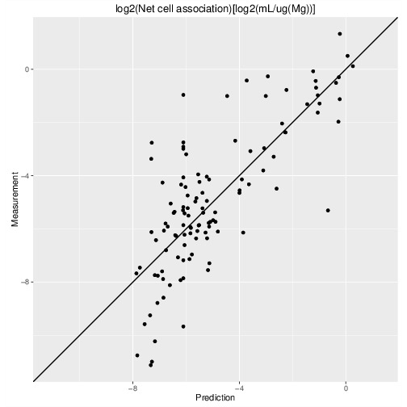

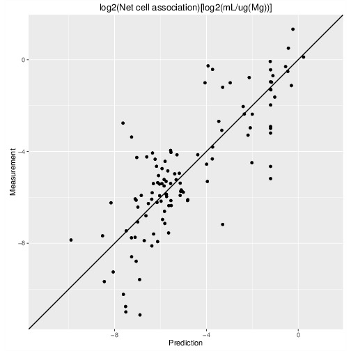

Correlation of predicted vs. measured values for five independent crossvalidations with *Proteomics* descriptors and local *random forest* models

# `nano-lazar` validation summary

- Best results: Protein interaction descriptors and random forest models
- Most results show no statistically significant difference
- Calculated fingerprints perform surprisingly well (RMSE comparable to best results) and do not require measured nanoparticle properties
- Local random forest models with nanoparticle fingerprints can be useful for screening purposes without physical measurements

# `nano-lazar` GUI

[figure not shown]

# `nano-lazar` GUI

[figure not shown]

# Reproducible research

Manuscript submitted to Frontiers in Pharmacology

- Open source code for lazar and publication
- Manuscript with direct source code links
- Docker image with
  - `lazar` libraries
  - Training data
  - Validation experiments
  - Software dependencies
  - Build system to recreate validations
  - Update facilities for code and data

# Links

**Nano-lazar GUI**

https://nano-lazar.in-silico.ch

**Lazar (source code)**

https://github.com/opentox/lazar

**Publication (source code)**

https://github.com/opentox/nano-lazar-paper

**Docker image**

https://hub.docker.com/r/insilicotox/nano-lazar-paper/

**Twitter**

https://twitter.com/insilicotox

**Email**

helma@in-silico.ch